# Project on Spatial Modeling and Visualization of Health Data using R: Lip Cancer in Scotland

Teshager Zerihun , Bahir Dar University, Bahir Dar, Ethiopia

Submitted to: Dr. Paula Moraga, Lancaster University, UK

```r
library(sp)
library(raster)
library(SpatialEpi)
data(scotland)
d <- scotland$data
map <- scotland$spatial.polygon
proj4string(map) <- "+init=epsg:27700 +proj=tmerc +lat_0=49 +lon_0=-2 +k=0.9996012717
+x_0=400000 +y_0=-100000 +datum=OSGB36 +units=km +no_defs +ellps=airy
+towgs84=446.448,-125.157,542.060,0.1502,0.2470,0.8421,-20.4894"
map <- spTransform(map, CRS("+proj=longlat +init=epsg:27700"))
rownames(d) <- d$county.names
map <- SpatialPolygonsDataFrame(map, d, match.ID = TRUE)
map$areaid <- map$county.names
d$areaid <- d$county.names
d$cases <- d$cases
d$Expected <- d$expected
d$covariate <- d$AFF
order <- match(map$areaid, d$areaid)
map@data <- d[order, c("areaid", "cases", "Expected", "covariate")]
map <- SpatialPolygonsDataFrame(map, d, match.ID = TRUE)
```

### 1. Description of Data

The data were collected from 56 Counties in Scotland about the number of male residents with lip cancer in the year between 1975 and 1980. The data had four objects described as:

1. geo: a table of county IDs, x-coordinates (eastings) and y-coordinates (northings) of the geographic centroid of each county in Scotland.
2. data: a table of county IDs, number of cases having lip cancer, proportion of the population engaged in agriculture, fishery or forestry (AFF), population and strata information.
3. spatial.polygon: is a Spatial Polygons class map of Scotland
4. polygon: is a polygon map of Scotland

### 2. Calculate Standardized Mortality Ratio (SMR) of Lip Cancer for each County of Scotland

Standardized Mortality Ratio (SMR) is the ratio of the obsreved number of death among males due to lip cancer and the expected number of death due lip cancer would be expected, based on the the age and sex-specific rates in the standard population and the population size of the study population by the same age/sex groups. Let $Y_i$ be the number of males having lip cancer in county $i$ and $E_i$ be expected numebr of males having lip cancer in county $i$ (number expected cases if area had the same disease rate as the standard population). Then the standard mortality ratio is denoted by SMR and gives as

$$SMR_i=\frac{Y_i}{E_i}$$

The $SMR_i$ which is greater than 1 indicates the presence of excess death in the population due to lip cancer.

Expected cases calculated using indirect standardization

$$E_i=\sum{r^s_j n_j^i}$$
for $j=1,\ldots,m$

where

$r^s_j$ is disease rate in strata j in standard population and given as

$$r^s_j=\frac{ \mbox{number disease cases}}{\mbox {population in strata j in standard population}}$$

$n^i_j$ population in strata j in area i

strata $j$ can indicate age group, sex, etc

```r
d$SMR=d$cases/d$Expected
d$SMR=round(d$SMR,2)
map <- SpatialPolygonsDataFrame(map, d, match.ID = TRUE)
```

### 3. Creating DT Table Create a DT table with columns area id, number of observed cases, number of expected cases, covariate, and SMR.

The DT table is created to show area id, observed and expected number of males with lip cancer, proportion of the population engaged in agriculture, fishing, or forestry (AFF) and standardized mortatlity rate (SMR) interactively. It is also used to visualize the order of the county in observed, expected and SMR of lip cancer in Scotland between 1975-1980.

```r
library(DT)
DT::datatable(map@data[, c("areaid", "cases", "Expected", "covariate", "SMR")],
              rownames = FALSE, options = list(pageLength = 10))
```

| areaid | cases | Expected | covariate | SMR |
| --- | --- | --- | --- | --- |
| skye-lochalsh | 9 | 1.4 | 0.16 | 6.43 |
| banff-buchan | 39 | 8.7 | 0.16 | 4.48 |
| caithness | 11 | 3 | 0.1 | 3.67 |
| berwickshire | 9 | 2.5 | 0.24 | 3.6 |
| ross-cromarty | 15 | 4.3 | 0.1 | 3.49 |
| orkney | 8 | 2.4 | 0.24 | 3.33 |
| moray | 26 | 8.1 | 0.1 | 3.21 |
| shetland | 7 | 2.3 | 0.07 | 3.04 |
| lochaber | 6 | 2 | 0.07 | 3 |
| gordon | 20 | 6.6 | 0.16 | 3.03 |

[output cut: 46 more lines]

Table 1: DT Table for area id, onserved and expected number of cases covariate and SMR

The first three county of scotland which had highest level of Standardized Mortality Ratio (SMR) were skye-lochalsh, banff-buchan and caithness, respectively. Among 56 counties in Scotland 33 of them had higher risk of lip cancer ($SMR_i$>1) as compared with the expected number of males with lip cancer in the standard population.

### 4. Explain the difference between SMR and RR.

1.Standard mortality ratio ($SMR$) is the ratio of Observed number of cases and expected number of cases due to specific cause of disease or death in the standardized population with different population structure. The cause of the disease or death may depends on the objectives of the investigations like death due to differnt cancers, malaria, HIV,…etc.

Mathematically, it is defined as:

$$SMR_i=\frac{Y_i}{E_i}$$
where $Y_i$ be the number of cases in a specific county and $E_i$ be expected numebr of cases in the given county. $i=1,\ldots,n$

2. Relative risk ($RR$is the ratio of the incidence of the death/disease in the exposed group and the incidence of death/disease in the unexposed group. Suppose that males who were engaged in agriculture, fishery or Forestry (AFF) are exposed to lip cancer and other working areas (NAFF) are categorized in the unexposed group (Lawson and Williams, 2001). The relative risk ($RR$) of county $i=1,\ldots,n$ is defined as

$$RR_i=\frac{P_{AFF(i)}}{P_{NFF(i)}}$$

where

$P_{AFF(i)}$: is proportion of males having lip cancer in the exposed group ($AFF$). $P_{NAFF(i)}$: is the proportion of males having lip cancer in the unexposed group ($NAFF$). county: $i=1,\ldots,n$

SMRs may be misleading and insufficiently reliable in areas with small populations.Incontrast, estimating relative risk using model-based approaches enable to incorporate covariates and borrow information from neighboring areas to improve local estimates, resulting in the smoothing of extreme rates based on small sample sizes. Therefore, model based estimation of RR gives more reliable estimate than SMR for area with small population size.

### 5. Fit a spatial model to obtain the RRs for each of the areas

The relative risk (RR) is estimated using model based apporach. Let $Y_i$ and $E_i$ be the observed and expected number of males having lip cancer in county $i$, respectively and let $\theta_i$ be the relative risk of lip cancer in county $i=1,\ldots,56$. The number of lip cancer cases given the relative risk (disease risk) follows a poisson distribution with ($E_i\times\theta_i$) mean rate of lip cancer occurrences. That is,

$$y_i|\theta_i\sim Poisson(E_i\times\theta_i),i=1,\ldots,n,$$

$$\log(\theta_i)=\beta_0 + \beta_1x_i +u_i +v_i.$$

where $\beta_0$ is the intercept or the log of the RR when all covariates and spatial effects are removed. $x_i$ is the proportion of males engaged in Agriculture, Forestry and Fishery (AFF) in county $i=1,\ldots,56.$

$u_i$ is an structured spatial effect to account for the spatial dependence between relative risks.

$v_i$ is an unstructured spatial effect to account for independent area-specific noise.

```r
library(Matrix)
library(spData)
library(spdep)
library(spDataLarge)
library(INLA)
n <- poly2nb(map)
head(n)
```

```
## [[1]]
## [1]  5  9 19
##
## [[2]]
## [1]  7 10
##
## [[3]]
## [1] 12
##
## [[4]]
## [1] 18 20 28
##
## [[5]]
## [1]  1 12 19
##
## [[6]]
## [1] 0
```

```r
nb2INLA("map.adj", n)
g <- inla.read.graph(filename = "map.adj")
```

The structured and unstructured spatial effects are assigned $1,\ldots,56$ from data at the map object.

```r
map$re_u <- 1:nrow(map@data)
map$re_v <- 1:nrow(map@data)
```

The observed number of lip cancer as a function of AFF, stuctured and unstructured spatial effects.

```r
formulas <- cases ~ covariate + f(re_u, model = "besag", graph = g, scale.model = TRUE) + f(re_v, model = "iid")
```

Modeling observed number of lip cancer given relative risk or disease risk using poisson distribution.

```r
result <- inla(formulas, family = "poisson", data = map@data, E = Expected, control.predictor = list(compute = TRUE))
```

```r
summary(result)
```

```
##
## Call:
## c("inla(formula = formulas, family = \"poisson\", data = map@data, ",  "    E = Expected, control.predictor = list(compute = TRUE))" )
##
## Time used:
##  Pre-processing    Running inla Post-processing           Total
##          0.5541          1.1247          0.1841          1.8629
##
## Fixed effects:
##               mean     sd 0.025quant 0.5quant 0.975quant    mode kld
## (Intercept) -0.305 0.1195    -0.5386  -0.3055    -0.0684 -0.3067   0
## covariate    4.330 1.2766     1.7435   4.3562     6.7702  4.4080   0
##
## Random effects:
## Name   Model
##  re_u   Besags ICAR model
## re_v   IID model
##
## Model hyperparameters:
##                        mean        sd 0.025quant  0.5quant 0.975quant
## Precision for re_u     4.15     1.449      2.022     3.914      7.629
## Precision for re_v 19340.41 19386.080   1347.025 13600.934  70978.769
##                        mode
## Precision for re_u    3.486
## Precision for re_v 3679.349
##
## Expected number of effective parameters(std dev): 28.54(3.533)
## Number of equivalent replicates : 1.962
##
## Marginal log-Likelihood:  -189.69
## Posterior marginals for linear predictor and fitted values computed
```

### 6. What is the effect of the covariate on the disease risk?

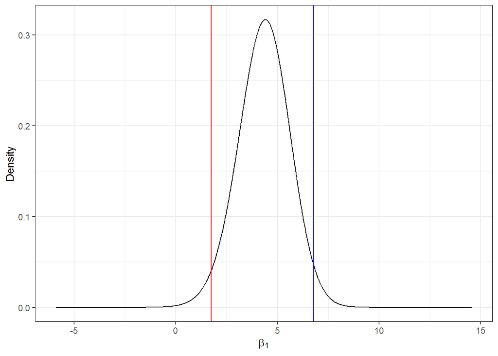

```r
library(ggplot2)
marginal <- inla.smarginal(result$marginals.fixed$covariate)
marginal <- data.frame(marginal)
ggplot(marginal, aes(x = x, y = y)) + geom_line() + labs(x = expression(beta[1]), y = "Density") +
  geom_vline(xintercept = c(result$summary.fixed[2,3],result$summary.fixed[2,5]), col = c("red","blue")) + theme_bw()
```

Fig 1: The 95% confidence interval of the effect of covariate ($\hat\beta_1$)) on the disease risk

The plot also showed that the 95% credible confidence interval of the coefficient of covariate (AFF) did not include zero and for a unit increase in the proportion of males engaged in AFF would have a higher log of lip cancer risk.

### 7. Create a DT table with columns area id, number of observed cases, number of expected cases, covariate,SMR, RR, lower and upper limits of 95% CI of RR.

In order to constract interactive table with area id, number of observed cases, number of expected cases, covariate, SMR, RR, lower and upper limits of the 95% CI of RR, we have attach the disease risk (RR) and its 95% CI from fitted values of the model to data at map object.

The disease risk estimates and uncertainty for each of the counties are given by the mean posterior and the 95% credible intervals of $\theta_i$, $i=1,\ldots,n$ which are in res$summary.fitted.values and attached to data at map object using the following command.

```r
map$RR <- round(result$summary.fitted.values[,"mean"],2)
map$LL <- round(result$summary.fitted.values[, "0.025quant"],2)
map$UL <- round(result$summary.fitted.values[, "0.975quant"],2)
```

```r
library(DT)
DT::datatable(map@data[, c("areaid", "cases", "Expected", "covariate", "SMR", "RR", "LL","UL")],
    rownames =FALSE, options=list(pageLength = 10),selection = c("multiple"),class="cell-border stripe", editable = FALSE)
```

| areaid | cases | Expected | covariate | SMR | RR | LL | UL |
| --- | --- | --- | --- | --- | --- | --- | --- |
| skye-lochalsh | 9 | 1.4 | 0.16 | 6.43 | 4.96 | 2.64 | 8.29 |
| banff-buchan | 39 | 8.7 | 0.16 | 4.48 | 4.4 | 3.17 | 5.82 |
| caithness | 11 | 3 | 0.1 | 3.67 | 3.62 | 1.92 | 5.88 |
| berwickshire | 9 | 2.5 | 0.24 | 3.6 | 3.08 | 1.63 | 5.11 |
| ross-cromarty | 15 | 4.3 | 0.1 | 3.49 | 3.33 | 2.04 | 4.97 |
| orkney | 8 | 2.4 | 0.24 | 3.33 | 2.98 | 1.49 | 5.07 |
| moray | 26 | 8.1 | 0.1 | 3.21 | 2.93 | 2.02 | 4.04 |
| shetland | 7 | 2.3 | 0.07 | 3.04 | 2.04 | 0.93 | 3.78 |
| lochaber | 6 | 2 | 0.07 | 3 | 2.1 | 1.16 | 3.5 |
| gordon | 20 | 6.6 | 0.16 | 3.03 | 2.97 | 1.98 | 4.19 |

[output cut: 46 more lines]

Table 2: DT Table of Lip cancer with area id, SMR, RR and other covariates

### 8. Create a leaflet map that shows RR values and give a short description of the map.

```r
library(leaflet)
l <- leaflet(map) %>% addTiles()
pal <- colorNumeric(palette = "YlOrRd", domain = map$RR)
l %>% addPolygons(color = "grey", weight = 1, fillColor = ~pal(RR), fillOpacity = 0.5) %>%
  addLegend(pal = pal, values = ~RR, opacity = 0.8, title = "RR", position = "bottomright")
```

[interactive chart not shown]

Fig 2: The leaflet map of relative risk of lip cancer in the county of Scotland between 1975 and 1980.

The estimated lip cancer risk of counties in Scotland is showed in an interactive map using leaflet. In the map, we add labels that appear when mouse hovers over the counties showing information about observed and expected counts, SMRs, males AFF proportions, RRs, and lower and upper limits of 95% credible intervals.

```r
pal <- colorNumeric(palette = "YlOrRd", domain = map$RR)
labels <- sprintf("<strong> %s </strong> <br/> Observed: %s <br/> Expected: %s <br/>
                  AFF proportion: %s <br/>SMR: %s <br/>RR: %s (%s, %s)",
                map$areaid, map$cases,  round(map$Expected, 2),  map$covariate, round(map$SMR, 2),
                  round(map$RR,2), round(map$LL, 2), round(map$UL, 2)) %>%
  lapply(htmltools::HTML)

leaflet(map) %>% addTiles() %>%
    addPolygons(color = "grey", weight = 1, fillColor = ~pal(RR),  fillOpacity = 0.5,
    highlightOptions = highlightOptions(weight = 4),
    label = labels,
labelOptions = labelOptions(style = list("font-weight" = "normal", padding = "3px 8px"),
    textsize = "15px", direction = "auto")) %>%
    addLegend(pal = pal, values = ~RR, opacity = 0.5, title = "RR", position = "bottomright")
```

[interactive chart not shown]

Fig 3: Interactive map of Lip Cancer risk in the county of Scotland between 1975 and 1980.

Counties shaded with dark red color had higher risk of lip cancer.Ingeneral, counties found in the Northern region of Scotland had higher lip cancer rate that the souther part of the country and we can see the name of the counties, observed and expected number of cases, SMR and RR of lip cancer in county by moving the mouse cursor on the interactive leaflet map.

### 10. Write a summary of the analysis conducted.

The lip cancer data were collected from 56 counties of Scotland between 1975 and 1980. The data have four objects which had several informations like county IDs, eating and northing of geographic centroid, observed number of cases, expected numebr of cases, proportion of populations engaged in agriculture, fishery or forestry (AFF), population and strata information, spatial Polygon class number map and ploygon map of Scotland. The objective of this study is to estimate the Standard mortality ratio (SMR) and disease risk (RR) of lip cancer among the counties of Scotland.

The SMR is a ratio of the observed number of cases and expected number of cases. The SMR may not be reliable in counties having smaller population size. However, estimating disease risk using model based approach or using INLA enable to incorparate covariate and borrow information from neighboring areas.